# Análise da atividade do GitHub

Problema 4 - Checkpoint 1

## Descrição dos Dados

Usaremos nesse estudo **amostra** de dados da atividade global do github. Os dados brutos contém a contagem de quantas pessoas editaram arquivos com cada extensão de arquivo em cada dia de 2016 e 2017 no [Github](https://github.com/).

```r
dados <- read.csv("github-users-committing-filetypes.csv")
```

Os dados originais possuem as seguintes informações:

- **file_extension**: Determina o tipo de arquivo que foi alterado e por consequência conseguimos determinar a linguagem de programação usada nesse arquivo.
- **month_day**: Dia do mês referente a observação.
- **the_month**: Mês referente a observação.
- **the_year**: Ano referente a observação.
- **users**: Número de pessoas que editaram arquivos com a extensão observada.

Para facilitar o estudo serão aplicadas algumas transformações nos dados, de forma a agrupar a data em um único campo e determinar a que dia da semana a data se refere.

```r
dados <- dados %>%
  unite("data", the_year, the_month, month_day, sep = "-") %>%
  mutate(data = as.Date(strptime(data, "%Y-%m-%d"))) %>%
  mutate(fds = is.weekend(data)) %>%
  mutate(dia_da_semana = weekdays(data))
```

Deste modo, serão incluidas as colunas:

- **data**: Data referente à modificação.
- **fds**: Valor lógico que indica se a data é um fim de semana (sábado ou domingo) ou não.
- **dia_da_semana**: Nome do dia da semana a que se refere a data.

O objetivo principal é compararmos duas linguagens de programação em função da sua popularidade nos dias úteis e nos nos fins de semana.

Nos dados dispomos de 42 linguagens, mas estamos interessados em apenas 2 delas, então usaremos as mais populares, ou seja, as que tiveram mais usuários no período estudado. Que são:

```r
dados_group <- dados %>%
  group_by(file_extension) %>%
  summarize(tot_users = sum(users))

kable(x = head(arrange(dados_group, desc(tot_users)), 2),
      col.names = c ("Extensão", "Total de usuários"),
        align = c('c'))
```

| Extensão | Total de usuários |
| --- | --- |
| md | 3805767 |
| js | 3093694 |

Assim, lidaremos com as linguagens **JavaScript** e **Markdown**

```r
dados_js <- dados %>%
  filter(file_extension == "js")

dados_md <- dados %>%
  filter(file_extension == "md")
```

### JavaScript

JavaScript é uma linguagem de programação interpretada. É atualmente a principal linguagem para programação client-side em navegadores web.<sup>[[1](https://pt.wikipedia.org/wiki/JavaScript)]</sup> A seguir observamos a distribuição de usuários dessa linguagem ao longo do tempo.

```r
dados_js_m <- dados_js %>%
  select(-c(file_extension, fds, dia_da_semana)) %>%
  remove_rownames %>%
  column_to_rownames(var="data") %>%
  as.xts()

highchart(type = "stock") %>%
  hc_title(text = "Timeline da Atividade de JavaScript") %>%
  hc_add_series(dados_js_m)
```

[interactive chart not shown]

### Markdown

Markdown é uma linguagem simples de marcação originalmente criada por John Gruber e Aaron Swartz. Markdown converte seu texto em XHTML válido.<sup>[[2](https://pt.wikipedia.org/wiki/Markdown)]</sup> A linha do tempo de modificações em Markdown é a seguinte:

```r
dados_md_m <- dados_md %>%
  select(-c(file_extension, fds, dia_da_semana)) %>%
  remove_rownames %>%
  column_to_rownames(var="data") %>%
  as.xts()

highchart(type = "stock") %>%
  hc_title(text = "Timeline da Atividade de Markdown") %>%
  hc_add_series(dados_md_m)
```

[interactive chart not shown]

## Perguntas

### 1 - Para cada uma delas, há uma diferença significativa na sua popularidade durante a semana e durante o fim de semana? Essa diferença é grande?

Neste caso, determinaremos o intervalo de confiança para a atividade dos programadores no dias úteis e no fim de semana. Usaremos a mediana, por ser uma medida estatística mais robusta.

Para **Markdown**:

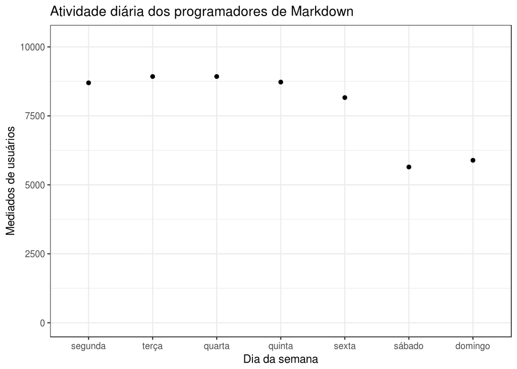

```r
dados_md %>%
  group_by(dia_da_semana) %>%
  summarise(usuarios = median(users)) %>%
  ggplot(aes(x = dia_da_semana, y = usuarios)) +
  geom_point() +
  ylim(0, max(dados_md$users)) +
  scale_x_discrete(limits=c("segunda", "terça", "quarta", "quinta", "sexta", "sábado", "domingo")) +
  labs(title = "Atividade diária dos programadores de Markdown", x = "Dia da semana", y = "Mediados de usuários")
```

É possível perceber uma diferença significativa de comportamento no fim de semana em relação aos dias úteis da semana. No entanto, como estamos interessados em obter conclusões a cerca de toda população de programadores em Markdown, e não somente sobre a amosta com a qual estamos lidando, usaremos *bootstrap* que é uma técnica de amostragem usada para realizar inferência e obter também o intervalo de confiança da diferença da atividade dos programadores Markdown durante a semana e no fim de semama.

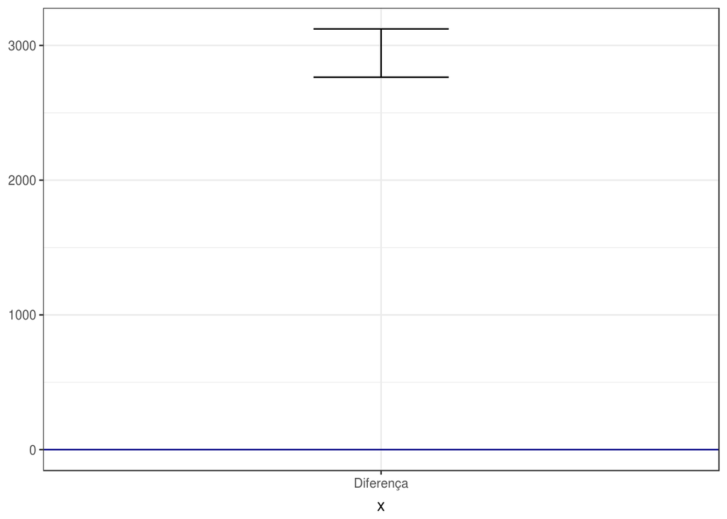

```r
median.md <- bootstrap2(dados_md$users,
                        treatment = dados_md$fds,
                        median,
                        R = 10000)

median.md.diff <- CI.percentile(median.md, probs = c(.025, .975))

data.frame(median.md.diff) %>%
  ggplot(aes(x = "Diferença", ymin = X2.5., ymax = X97.5.)) +
  geom_errorbar(width = .2) +
  geom_hline(yintercept = 0, colour = "darkblue")
```

Essa visualização exibe, com 95% de confiança, a diferença das medianas entre a atividade no fim de semana e nos dias úteis. O intervalo é de 2764, 3122.3289342. Como esse intervalo *não inclui o zero*, podemos concluir que existe mais atividade dos programadores durante a semana do que no sábado e no domingo.

Para **JavaScript**:

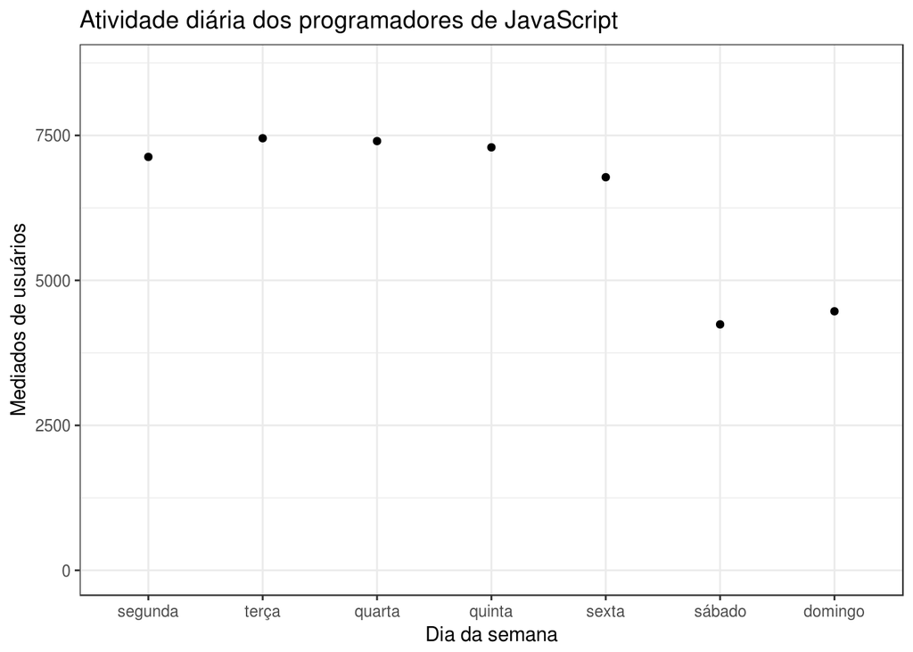

```r
dados_js %>%
  group_by(dia_da_semana) %>%
  summarise(usuarios = median(users)) %>%
  ggplot(aes(x = dia_da_semana, y = usuarios)) +
  geom_point() +
  ylim(0, max(dados_js$users)) +
  scale_x_discrete(limits=c("segunda", "terça", "quarta", "quinta", "sexta", "sábado", "domingo")) +
  labs(title = "Atividade diária dos programadores de JavaScript", x = "Dia da semana", y = "Mediados de usuários")
```

Como no caso anterior, é observada uma queda de produtividade nos finais de semana, mas, sob as meśmas justificativas também lançaremos mão aqui das mesmas técnicas para obter conclusões sobre a população.

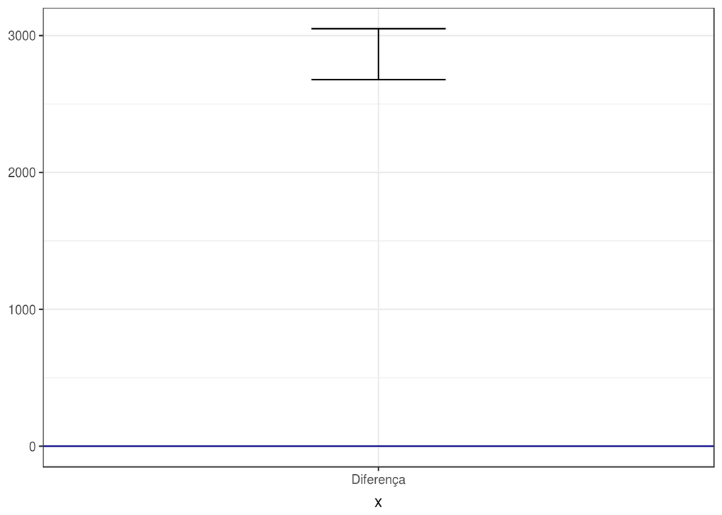

```r
median.js <- bootstrap2(dados_js$users,
                        treatment = dados_js$fds,
                        median,
                        R = 10000)

median.js.diff <- CI.percentile(median.js, probs = c(.025, .975))

data.frame(median.js.diff) %>%
  ggplot(aes(x = "Diferença", ymin = X2.5., ymax = X97.5.)) +
  geom_errorbar(width = .2) +
  geom_hline(yintercept = 0, colour = "darkblue")
```

No caso de JavaScript a diferença das medianas com 95% de confiança está entre 2678.5, 3050.3289342 o que, como no caso anterior, está acima do zero, logo, há uma diferença significativa entre os número de usuários dessa linguagem, sendo de volume maior durante a semana que no final dela.

### 2 - Existe uma diferença significativa entre as duas linguagens na sua variação de popularidade nos finais de semana?

Aqui estamos interessados apenas na variação que ocorre nos finais de semana, e ao invés da esturamos separadamente as linguagens, faremos a comparação delas

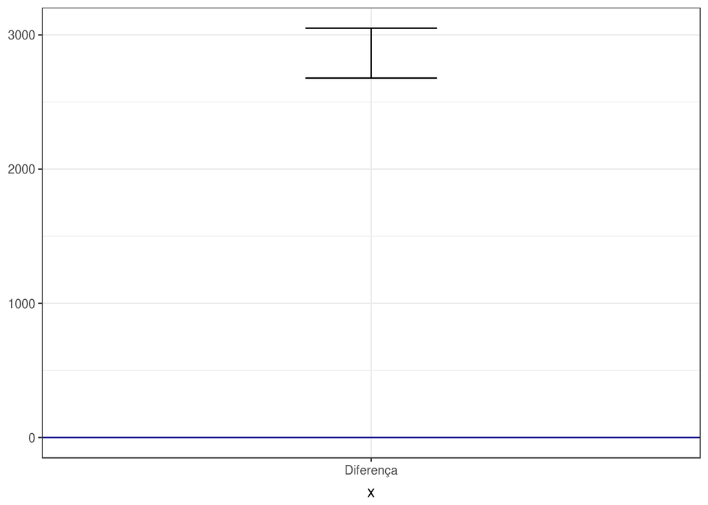

```r
sd.diff <- bootstrap2(data = (dados_js %>% filter(fds == TRUE))$users,
                      data2 = (dados_md %>% filter(fds == TRUE))$users,
                      sd,
                      R = 10000)
sd.diff.ci <- CI.percentile(median.js, probs = c(.025, .975))


data.frame(sd.diff.ci) %>%
  ggplot(aes(x = "Diferença", ymin = X2.5., ymax = X97.5.)) +
  geom_errorbar(width = .2) +
  geom_hline(yintercept = 0, colour = "darkblue")
```